# **Deep Learning Project: Street View Housing Number Digit Recognition**

# **Marks: 60**

## **Context**

One of the most interesting tasks in deep learning is to recognize objects in natural scenes. The ability to process visual information using machine learning algorithms can be very useful as demonstrated in various applications.

The SVHN dataset contains over 600,000 labeled digits cropped from street-level photos. It is one of the most popular image recognition datasets. It has been used in neural networks created by Google to improve the map quality by automatically transcribing the address numbers from a patch of pixels. The transcribed number with a known street address helps pinpoint the location of the building it represents.

## **Objective**

Our objective is to predict the number depicted inside the image by using Artificial or Fully Connected Feed Forward Neural Networks and Convolutional Neural Networks. We will go through various models of each and finally select the one that is giving us the best performance.

## **Dataset**

Here, we will use a subset of the original data to save some computation time. The dataset is provided as a .h5 file. The basic preprocessing steps have been applied on the dataset.

## **Mount the drive**

Let us start by mounting the Google drive. You can run the below cell to mount the Google drive.

```python
from google.colab import drive
drive.mount('/content/drive')
```

## **Importing the necessary libraries**

```python
# Hide warnings
import warnings
warnings.filterwarnings("ignore")

# Import this library to help read the h5 data file
import h5py

# Import data visualization and manipulation libraries
import numpy as np
import matplotlib.pyplot as plt
import seaborn as sns
import pandas as pd

# Import deep learning model libraries
import keras
import tensorflow as tf
from tensorflow.keras.models import Sequential
from tensorflow.keras.layers import Dense, Dropout, Flatten, Conv2D, MaxPooling2D, BatchNormalization, Activation, LeakyReLU
from tensorflow.keras.optimizers import Adam
from tensorflow.keras import backend
from sklearn.metrics import classification_report
from sklearn.metrics import confusion_matrix
import random
```

**Let us check the version of tensorflow.**

```python
# Display tensorflow version
print (tf.__version__)
```

```
2.12.0
```

## **Load the dataset**

- Let us now load the dataset that is available as a .h5 file.
- Split the data into the train and the test dataset.

```python
# Open the HDF5 file
file = h5py.File('/content/drive/MyDrive/Colab Notebooks/SVHN_single_grey1.h5', 'r')

# Get the key names to understand what is in the file
dataset_names = list(file.keys())

# Print the key names from the file
for name in dataset_names:
    print(name)

# Access dataset values and assign variables
x_test_data = file['X_test']
y_test_data = file['y_test']
x_train_data = file['X_train']
y_train_data = file['y_train']
x_val_data = file['X_val']
y_val_data = file['y_val']

# Convert test data into arrays for easier manipulation and assign to variables
x_test = x_test_data[()]
y_test = y_test_data[()]

# Convert training data into arrays for easier manipulation and assign to variables
x_train = x_train_data[()]
y_train= y_train_data[()]

# Convert validation data into arrays for easier manipulation and assign to variables
x_val = x_val_data[()]
y_val = y_val_data[()]

# Obtain number of classes in the train data
unique_classes_in_y_train = set(y_train[:])

# Count the number of unique classes
number_of_classes = len(unique_classes_in_y_train)

# Get the names of the unique classes
print("Names of classes:", unique_classes_in_y_train)

# Print the number of classes
print("Number of classes in training data is", number_of_classes)

# Close the file
file.close()
```

```
X_test
X_train
X_val
y_test
y_train
y_val
Names of classes: {0, 1, 2, 3, 4, 5, 6, 7, 8, 9}
Number of classes in training data is 10
```

Check the number of images in the training and the testing dataset.

```python
# test dataset where x has the image and y has the label
print("x_test=", x_test.shape)

# train dataset where x has the image and y has the label
print("x_train=", x_train.shape)
```

```
x_test= (18000, 32, 32)
x_train= (42000, 32, 32)
```

**Observation:**

- There are 18000 images in the test dataset.
- There are 42000 images in the training dataset.
- There are ten unique classifications: 0, 1, 2, 3, 4, 5, 6, 7, 8, 9.
- Because there are more than two classifications, this is a multi-classification dataset.
- Each image is 32px by 32px.
- The h5 file already has data been split into test, validation, and training variables.

## **Visualizing images**

- Use X_train to visualize the first 10 images.
- Use Y_train to print the first 10 labels.

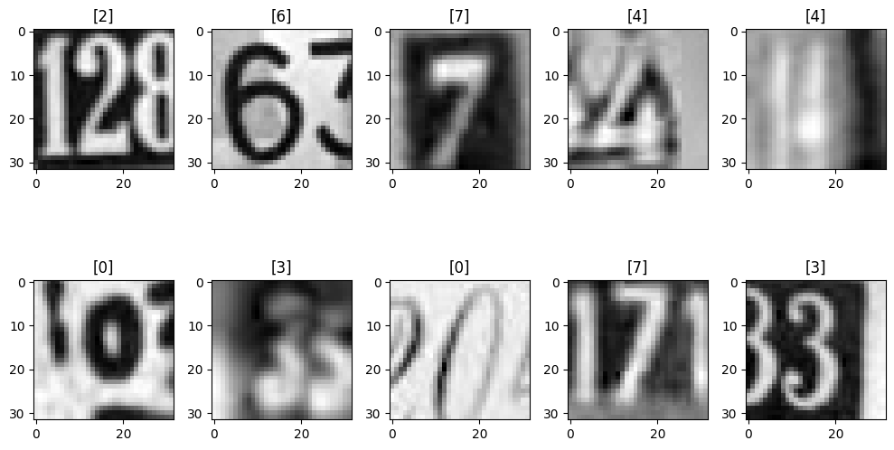

```python
# Show two rows of five images and set the dimensions of entire figure with width of 10 and height of 6
fig, axes = plt.subplots(nrows=2, ncols=5, figsize=(10,6))

for i, ax in enumerate(axes.flat): # for each image
    ax.imshow(x_train[i], cmap='gray')  # set image to grayscale
    ax.axis('on') # display image axis
    ax.set_title([y_train[i]]) # display the associated label from y_train

plt.tight_layout() # improve spacing around each image for readability
plt.show() # display images
```

## **Data preparation**

- Print the shape and the array of pixels for the first image in the training dataset.
- Normalize the train and the test dataset by dividing by 255.
- Print the new shapes of the train and the test dataset.
- One-hot encode the target variable.

```python
# Display shape of the first image in x_train
print("x_train[0] shape =", x_train[0].shape, end='\n\n')

# Display array of pixels for first image in x_train
print("x_train[0] array =",  x_train[0])
```

```
x_train[0] shape = (32, 32)

x_train[0] array = [[ 33.0704  30.2601  26.852  ...  71.4471  58.2204  42.9939]
 [ 25.2283  25.5533  29.9765 ... 113.0209 103.3639  84.2949]
 [ 26.2775  22.6137  40.4763 ... 113.3028 121.775  115.4228]
 ...
 [ 28.5502  36.212   45.0801 ...  24.1359  25.0927  26.0603]
 [ 38.4352  26.4733  23.2717 ...  28.1094  29.4683  30.0661]
 [ 50.2984  26.0773  24.0389 ...  49.6682  50.853   53.0377]]
```

### **Normalize the train and the test data**

```python
# Normalize the training data to prevent the vanishing/exploding gradient problem
x_train_normalized = x_train/255

# Normalize the test data to prevent the vanishing/exploding gradient problem
x_test_normalized = x_test/255

# Print the first image array for x_train_normalized
print("x_train_normalized[0] array=", x_train_normalized[0])
```

```
x_train_normalized[0] array= [[0.12968785 0.11866706 0.10530196 ... 0.2801847  0.2283153  0.16860352]
 [0.09893451 0.10020902 0.1175549  ... 0.4432192  0.40534863 0.33056822]
 [0.10304902 0.08868118 0.15873058 ... 0.44432473 0.47754902 0.45263842]
 ...
 [0.11196157 0.14200786 0.17678471 ... 0.09465059 0.09840274 0.10219726]
 [0.15072627 0.10381687 0.09126157 ... 0.11023294 0.11556196 0.11790627]
 [0.19724864 0.10226392 0.0942702  ... 0.19477727 0.19942354 0.20799099]]
```

Print the shapes of Training and Test data

```python
# Display x_train shape
print("x_train_normalized =", x_train_normalized.shape)

# Display x_test shape
print("x_test_normalized =", x_test_normalized.shape)
```

```
x_train_normalized = (42000, 32, 32)
x_test_normalized = (18000, 32, 32)
```

### **One-hot encode output**

```python
# One-hot encode the training y values
y_train_encoded = tf.keras.utils.to_categorical(y_train)

# One-hot encode the test y values
y_test_encoded = tf.keras.utils.to_categorical(y_test)

# To view encoding for the first label in train and test
print("y_train_encoded[0] =", y_train_encoded[0])
print("y_test_encoded[0] =", y_test_encoded[0])
```

```
y_train_encoded[0] = [0. 0. 1. 0. 0. 0. 0. 0. 0. 0.]
y_test_encoded[0] = [0. 1. 0. 0. 0. 0. 0. 0. 0. 0.]
```

**Observation:**

- It appears that if multiple numbers are displayed in an image, the middle or most visible number is the only one classified. Because of this, only digits less than 10 will be classified (e.g., the first image shows 128, but the associated label is 2).
- The pixel values in each image array are floats.
- The first image in y_train_encoded is classified as 2, and the first image in the y_train_encoded is classified as 1.
- The training and test dataset shape dimensions have remained the same.
- In the training images, the typeface and color of each number varies by image.

## **Model Building**

Now that we have done the data preprocessing, let's build an ANN model.

### Fix the seed for random number generators

```python
# To ensure results can be reproduced, set the random seed
# 42 picked because it is the perfect number according to Douglas Adams

np.random.seed(42)

random.seed(42)

tf.random.set_seed(42)
```

### **Model Architecture**

- Write a function that returns a sequential model with the following architecture:
  - First hidden layer with **64 nodes and the relu activation** and the **input shape = (1024, )**
  - Second hidden layer with **32 nodes and the relu activation**
  - Output layer with **activation as 'softmax' and number of nodes equal to the number of classes, i.e., 10**
  - Compile the model with the **loss equal to categorical_crossentropy, optimizer equal to Adam(learning_rate = 0.001), and metric equal to 'accuracy'**. Do not fit the model here, just return the compiled model.
- Call the nn_model_1 function and store the model in a new variable.
- Print the summary of the model.
- Fit on the train data with a **validation split of 0.2, batch size = 128, verbose = 1, and epochs = 20**. Store the model building history to use later for visualization.

### **Build and train an ANN model as per the above mentioned architecture.**

```python
# Create a Sequential ANN model
nn_model_1 = Sequential([

    # Flatten input data to a lower dimension
    Flatten(input_shape = (1024,)),

    # Create two hidden layers
    Dense(64, activation = 'relu'),
    Dense(32, activation = 'relu'),

    # Create the output layer
    Dense(number_of_classes, activation = 'softmax')
])

# Set optimizer equal to Adam with a learning rate of 0.001
optimizer = Adam(learning_rate=0.001)

# Compile model
nn_model_1.compile(optimizer, loss = 'categorical_crossentropy',  metrics = ['accuracy'])

# Print summary of the model
nn_model_1.summary()
```

```
Model: "sequential_1"
_________________________________________________________________
 Layer (type)                Output Shape              Param #
=================================================================
 flatten_1 (Flatten)         (None, 1024)              0

 dense_2 (Dense)             (None, 64)                65600

 dense_3 (Dense)             (None, 32)                2080

 dense_4 (Dense)             (None, 10)                330

=================================================================
Total params: 68,010
Trainable params: 68,010
Non-trainable params: 0
_________________________________________________________________
```

### **Plot the Training and Validation Accuracies and write down your Observations.**

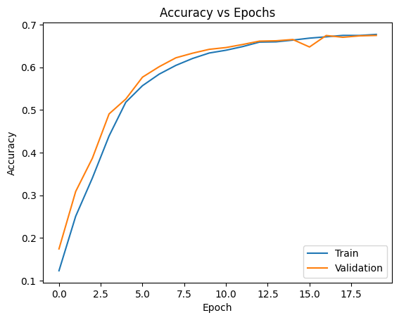

```python
# Reshape input layer
new_shape = (x_train_normalized.shape[0], -1)
reshaped_x_train_data = np.reshape(x_train_normalized, new_shape)

# Fit model and save to a variable
history_1 = nn_model_1.fit(reshaped_x_train_data, y_train_encoded, validation_split=0.2, batch_size = 128, epochs=20, verbose=1)

# Obtain training and validation accuracies from history_1
plt.plot(history_1.history['accuracy'])
plt.plot(history_1.history['val_accuracy'])
plt.title('Accuracy vs Epochs')
plt.ylabel('Accuracy')
plt.xlabel('Epoch')
plt.legend(['Train', 'Validation'], loc='lower right')
plt.show()
```

**Observations:**___****

- The accuracy for the training and validation did not get above 68%.
- The validation and training loss generally decreased over the epochs, but the loss values overall were still really high (1.0420 for train and 1.0535 for validation).
- The training accuracy and validation accuracy generally followed the same curve (with the validation accuracy varying slightly).

Let's build one more model with higher complexity and see if we can improve the performance of the model.

First, we need to clear the previous model's history from the Keras backend. Also, let's fix the seed again after clearing the backend.

```python
# Clears Keras background
backend.clear_session()

# Fixes the seed to 42
np.random.seed(42)
random.seed(42)
tf.random.set_seed(42)
```

### **Second Model Architecture**

- Write a function that returns a sequential model with the following architecture:
  - First hidden layer with **256 nodes and the relu activation** and the **input shape = (1024, )**
  - Second hidden layer with **128 nodes and the relu activation**
  - Add the **Dropout layer with the rate equal to 0.2**
  - Third hidden layer with **64 nodes and the relu activation**
  - Fourth hidden layer with **64 nodes and the relu activation**
  - Fifth hidden layer with **32 nodes and the relu activation**
  - Add the **BatchNormalization layer**
  - Output layer with **activation as 'softmax' and number of nodes equal to the number of classes, i.e., 10** -Compile the model with the **loss equal to categorical_crossentropy, optimizer equal to Adam(learning_rate = 0.0005), and metric equal to 'accuracy'**. Do not fit the model here, just return the compiled model.
- Call the nn_model_2 function and store the model in a new variable.
- Print the summary of the model.
- Fit on the train data with a **validation split of 0.2, batch size = 128, verbose = 1, and epochs = 30**. Store the model building history to use later for visualization.

### **Build and train the new ANN model as per the above mentioned architecture**

```python
nn_model_2 = Sequential([

    # Lower the dimensionality of the input
    Flatten(input_shape = (1024,)),

    # Create first and second hidden layers
    Dense(256, activation = 'relu'),
    Dense(128, activation = 'relu'),

    # Inactivate a random 20% of the neurons to help prevent overfitting
    Dropout(0.20),

    # Create third, fourth, and fifth hidden layers
    Dense(64, activation = 'relu'),
    Dense(64, activation = 'relu'),
    Dense(32, activation = 'relu'),

    #Add normalization layer
    BatchNormalization(),

    # Add an output layer
    Dense(number_of_classes, activation = 'softmax')
])

# Set optimizer equal to Adam with a learning rate of 0.0005
optimizer = Adam(learning_rate=0.0005)

# Compile model
nn_model_2.compile(optimizer, loss = 'categorical_crossentropy',  metrics = ['accuracy'])

# Print summary of the model
nn_model_2.summary()
```

```
Model: "sequential"
_________________________________________________________________
 Layer (type)                Output Shape              Param #
=================================================================
 flatten (Flatten)           (None, 1024)              0

 dense (Dense)               (None, 256)               262400

 dense_1 (Dense)             (None, 128)               32896

 dropout (Dropout)           (None, 128)               0

 dense_2 (Dense)             (None, 64)                8256

 dense_3 (Dense)             (None, 64)                4160

 dense_4 (Dense)             (None, 32)                2080

 batch_normalization (BatchN  (None, 32)               128
 ormalization)

 dense_5 (Dense)             (None, 10)                330

=================================================================
Total params: 310,250
Trainable params: 310,186
Non-trainable params: 64
_________________________________________________________________
```

### **Plot the Training and Validation Accuracies and write down your Observations.**

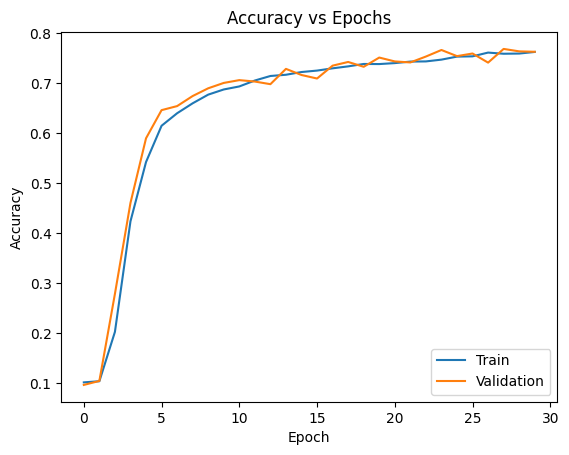

```python
# Fit model to the reshaped training data and save the model to a variable
history_2 = nn_model_2.fit(reshaped_x_train_data, y_train_encoded, validation_split=0.2, batch_size = 128, epochs=30, verbose=1)

# Obtain training and validation accuracies from history_2
plt.plot(history_2.history['accuracy'])
plt.plot(history_2.history['val_accuracy'])
plt.title('Accuracy vs Epochs')
plt.ylabel('Accuracy')
plt.xlabel('Epoch')
plt.legend(['Train', 'Validation'], loc='lower right')
plt.show()
```

**Observations:**___****

- There were 310,250 training parameters used for this model.
- The training loss generally improved with each epoch, and the validation loss varied more but generally decreased over all epochs. The losses are still high (0.7430 for train and 0.7616 for validation).
- The accuracies for validation and train improved from the first ANN model but did not get above 77%.
- The validation accuracy varied from the train accuracy slope over the 30 epochs.

## **Predictions on the test data**

- Make predictions on the test set using the second model.
- Print the obtained results using the classification report and the confusion matrix.
- Final observations on the obtained results.

```python
# Reshape test data
new_shape = (x_test_normalized.shape[0], -1)
reshaped_x_test_data = np.reshape(x_test_normalized, new_shape)

# Make predictions on the test set
y_pred_test = nn_model_2.predict(reshaped_x_test_data)
y_pred_test = [np.argmax(i) for i in y_pred_test]
```

**Note:** Earlier, we noticed that each entry of the target variable is a one-hot encoded vector but to print the classification report and confusion matrix, we must convert each entry of y_test to a single label.

```python
# Convert y_test to a single label
y_test_single_label = np.argmax(y_test_encoded, axis=1)

# Print y_test_single_label
print(y_test_single_label.shape)
```

```
(18000,)
```

### **Print the classification report and the confusion matrix for the test predictions. Write your observations on the final results.**

```
              precision    recall  f1-score   support

           0       0.84      0.75      0.79      1814
           1       0.74      0.79      0.77      1828
           2       0.77      0.80      0.79      1803
           3       0.62      0.77      0.69      1719
           4       0.79      0.83      0.81      1812
           5       0.76      0.68      0.72      1768
           6       0.80      0.74      0.77      1832
           7       0.83      0.77      0.80      1808
           8       0.72      0.72      0.72      1812
           9       0.75      0.74      0.75      1804

    accuracy                           0.76     18000
   macro avg       0.76      0.76      0.76     18000
weighted avg       0.76      0.76      0.76     18000
```

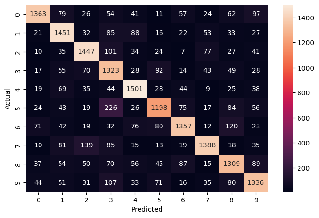

```python
# Print classification report
print(classification_report(y_test_single_label, y_pred_test))

# Set up confusion matrix
cm_1 = confusion_matrix(y_test, y_pred_test)
plt.figure(figsize = (8,5))
sns.heatmap(cm_1, annot = True, fmt= '.0f')
plt.ylabel('Actual')
plt.xlabel('Predicted')

# Show matrix
plt.show()
```

**Final Observations:**__****

- The accuracy of the second model was 76%.
- The highest accurately predicted number was 4 with 1501 instances.
- The most inaccurate prediction was when an image was predicted as 3 when it was actually 5 in 226 instances.
- While the majority of predictions were accurate, lots of predictions were still inaccurate with this model.

## **Using Convolutional Neural Networks**

### **Load the dataset again and split the data into the train and the test dataset.**

```python
# Open the HDF5 file
file = h5py.File('/content/drive/MyDrive/Colab Notebooks/SVHN_single_grey1.h5', 'r')

# Access dictionary names
x_test_data = file['X_test']
y_test_data = file['y_test']
x_train_data = file['X_train']
y_train_data = file['y_train']
x_val_data = file['X_val']
y_val_data = file['y_val']

# Convert test dictionaries to arrays and assign variable names
x_test_cnn = x_test_data[()]
y_test_cnn = y_test_data[()]

# Convert train dictionaries to arrays and assign variable names
x_train_cnn = x_train_data[()]
y_train_cnn= y_train_data[()]

# Convert validation dictionaries to arrays and assign variable names
x_val_cnn = x_val_data[()]
y_val_cnn = y_val_data[()]

# Obtain number of classes in the train data
unique_classes_in_y_train_cnn = set(y_train_cnn[:])

# Count the number of unique classes
number_of_classes_cnn = len(unique_classes_in_y_train_cnn)

# Close the file
file.close()
```

Check the number of images in the training and the testing dataset.

```python
# Get the number of images and each image dimension in the training dataset
print("x_train_cnn =", x_train_cnn.shape)

# Get the number of images and each image dimension in the testing dataset
print("x_test_cnn =", x_test_cnn.shape)
```

```
x_train_cnn = (42000, 32, 32)
x_test_cnn = (18000, 32, 32)
```

**Observation:**

- There are 42000 images in the training dataset, and each image has the dimensions of 32x32 pixels.
- There are 18000 images in the test dataset, and each image has the dimensions of 32x32 pixels.

## **Data preparation**

- Print the shape and the array of pixels for the first image in the training dataset.
- Reshape the train and the test dataset because we always have to give a 4D array as input to CNNs.
- Normalize the train and the test dataset by dividing by 255.
- Print the new shapes of the train and the test dataset.
- One-hot encode the target variable.

```python
# Print shape and array of pixels for first image in the training dataset
print("x_train_cnn[0].shape =", x_train_cnn[0].shape)
print("x_train_cnn[0] =", x_train_cnn[0])
```

```
x_train_cnn[0].shape = (32, 32)
x_train_cnn[0] = [[ 33.0704  30.2601  26.852  ...  71.4471  58.2204  42.9939]
 [ 25.2283  25.5533  29.9765 ... 113.0209 103.3639  84.2949]
 [ 26.2775  22.6137  40.4763 ... 113.3028 121.775  115.4228]
 ...
 [ 28.5502  36.212   45.0801 ...  24.1359  25.0927  26.0603]
 [ 38.4352  26.4733  23.2717 ...  28.1094  29.4683  30.0661]
 [ 50.2984  26.0773  24.0389 ...  49.6682  50.853   53.0377]]
```

Reshape the dataset to be able to pass them to CNNs. Remember that we always have to give a 4D array as input to CNNs

```python
# Reshape train and test data to have a fourth dimension
x_train_cnn_reshaped = x_train_cnn.reshape((x_train_cnn.shape[0]), 32, 32, 1)
x_test_cnn_reshaped = x_test_cnn.reshape((x_test_cnn.shape[0]), 32, 32, 1)

# Print the first image pixels from the reshaped train and test data
print("x_train_cnn_reshaped[0] =", x_train_cnn_reshaped[0], end='\n\n')
print("x_test_cnn_reshaped[0] =", x_test_cnn_reshaped[0])
```

[output not shown]

[output cut: 44 more lines]

[output not shown]

Normalize inputs from 0-255 to 0-1

```python
# Normalize the inputs
x_train_cnn_normalized = x_train_cnn_reshaped.astype('float32')/255.0
x_test_cnn_normalized = x_test_cnn_reshaped.astype('float32')/255.0

# Print to view the first image pixels from the normalized train and test
print("x_train_cnn_normalized[0] =", x_train_cnn_normalized[0], end='\n\n')
print("x_test_cnn_normalized[0] =", x_test_cnn_normalized[0])
```

[output not shown]

[output cut: 44 more lines]

[output not shown]

Print New shape of Training and Test

```python
# Print the shape of training data
print("x_train_cnn_normalized =", x_train_cnn_normalized.shape)

# Print the shape of test data
print("x_test_cnn_normalize =", x_test_cnn_normalized.shape)
```

```
x_train_cnn_normalized = (42000, 32, 32, 1)
x_test_cnn_normalize = (18000, 32, 32, 1)
```

### **One-hot encode the labels in the target variable y_train and y_test.**

```python
# One-hot encode the training y data
y_train_cnn_encoded = tf.keras.utils.to_categorical(y_train_cnn)

# One-hot encode the test y data
y_test_cnn_encoded = tf.keras.utils.to_categorical(y_test_cnn)

# Print first row in training and test data
print("y_train_cnn_encoded[0] =", y_train_cnn_encoded[0])
print("y_test_cnn_encoded[0] =", y_test_cnn_encoded[0])
```

```
y_train_cnn_encoded[0] = [0. 0. 1. 0. 0. 0. 0. 0. 0. 0.]
y_test_cnn_encoded[0] = [0. 1. 0. 0. 0. 0. 0. 0. 0. 0.]
```

**Observation:**

- The first image in the train dataset is classified as 2.
- The first image in the test dataset is classified as 1.
- The train and test data is now in four dimensions.
- Normalizing the data brought the pixel values between 0-1 which will help prevent the Vanishing/Exploding Gradient problem.

## **Model Building**

Now that we have done data preprocessing, let's build a CNN model. Fix the seed for random number generators

```python
# Fix the seed for random number generators
np.random.seed(42)
random.seed(42)
tf.random.set_seed(42)
```

### **Model Architecture**

- **Write a function** that returns a sequential model with the following architecture:
  - First Convolutional layer with **16 filters and the kernel size of 3x3**. Use the **'same' padding** and provide the **input shape = (32, 32, 1)**
  - Add a **LeakyRelu layer** with the **slope equal to 0.1**
  - Second Convolutional layer with **32 filters and the kernel size of 3x3 with 'same' padding**
  - Another **LeakyRelu** with the **slope equal to 0.1**
  - A **max-pooling layer** with a **pool size of 2x2**
  - **Flatten** the output from the previous layer
  - Add a **dense layer with 32 nodes**
  - Add a **LeakyRelu layer with the slope equal to 0.1**
  - Add the final **output layer with nodes equal to the number of classes, i.e., 10** and **'softmax' as the activation function**
  - Compile the model with the **loss equal to categorical_crossentropy, optimizer equal to Adam(learning_rate = 0.001), and metric equal to 'accuracy'**. Do not fit the model here, just return the compiled model.
- Call the function cnn_model_1 and store the output in a new variable.
- Print the summary of the model.
- Fit the model on the training data with a **validation split of 0.2, batch size = 32, verbose = 1, and epochs = 20**. Store the model building history to use later for visualization.

### **Build and train a CNN model as per the above mentioned architecture.**

```python
# Create a CNN Sequential model
cnn_model_1 = Sequential([
   # Create first convolutional layer
   Conv2D(16, (3, 3), activation='relu', padding="same", input_shape=(32, 32, 1)),

   # Add a LeakyRelu layer
   LeakyReLU(alpha=0.1),

   # Create the second convolutional layer
   Conv2D(32, (3, 3), activation='relu', padding="same", input_shape=(32, 32, 1)),

   # Add another leaky reLU layer
   LeakyReLU(alpha=0.1),

   # Add a max-pooling layer
   MaxPooling2D((2, 2)),

   # Flatten
   Flatten(),

   # Add a dense layer with 32 nodes
   Dense(32, activation = 'relu'),

   # Add a third leaky reLU layer
   LeakyReLU(alpha=0.1),

   # Add an output layer
   Dense(number_of_classes, activation = 'softmax')

])

# Set optimizer equal to Adam with a learning rate of 0.001
optimizer = Adam(learning_rate=0.001)

# Compile model
cnn_model_1.compile(optimizer, loss = 'categorical_crossentropy',  metrics = ['accuracy'])

# Print summary of the model
cnn_model_1.summary()
```

```
Model: "sequential_1"
_________________________________________________________________
 Layer (type)                Output Shape              Param #
=================================================================
 conv2d (Conv2D)             (None, 32, 32, 16)        160

 leaky_re_lu (LeakyReLU)     (None, 32, 32, 16)        0

 conv2d_1 (Conv2D)           (None, 32, 32, 32)        4640

 leaky_re_lu_1 (LeakyReLU)   (None, 32, 32, 32)        0

 max_pooling2d (MaxPooling2D  (None, 16, 16, 32)       0
 )

 flatten_1 (Flatten)         (None, 8192)              0

 dense_6 (Dense)             (None, 32)                262176

 leaky_re_lu_2 (LeakyReLU)   (None, 32)                0

 dense_7 (Dense)             (None, 10)                330

=================================================================
Total params: 267,306
Trainable params: 267,306
Non-trainable params: 0
_________________________________________________________________
```

### **Plot the Training and Validation Accuracies and Write your observations.**

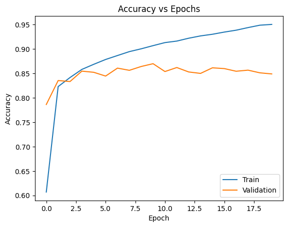

```python
# Fit the training data to the model
history_3 = cnn_model_1.fit(x_train_cnn_normalized, y_train_cnn_encoded, validation_split=0.2, batch_size = 32, epochs=20, verbose=1)

# Obtain training and validation accuracies from history_3
plt.plot(history_3.history['accuracy'])
plt.plot(history_3.history['val_accuracy'])
plt.title('Accuracy vs Epochs')
plt.ylabel('Accuracy')
plt.xlabel('Epoch')
plt.legend(['Train', 'Validation'], loc='lower right')
plt.show()
```

**Observations:**__****

- The accuracy of the training data was just above 95%, and the accuracy of the validation ended just below 85%.
- The loss for the training data decreased over each epoch.
- The validation loss dropped until the seventh epoch and then varied between slightly dropping or slightly increasing.
- Compared to the two ANN models previously shown, this CNN model ended with a smaller loss by the last epoch for both validation and training. The final loss scores were 0.1576 for training and 0.6877 for validation.
- This CNN model has 267,306 parameters.

Let's build another model and see if we can get a better model with generalized performance.

First, we need to clear the previous model's history from the Keras backend. Also, let's fix the seed again after clearing the backend.

```python
# Clear Keras backend
backend.clear_session()

# Fixes the seed to 42
np.random.seed(42)
random.seed(42)
tf.random.set_seed(42)
```

### **Second Model Architecture**

- Write a function that returns a sequential model with the following architecture:
  - First Convolutional layer with **16 filters and the kernel size of 3x3**. Use the **'same' padding** and provide the **input shape = (32, 32, 1)**
  - Add a **LeakyRelu layer** with the **slope equal to 0.1**
  - Second Convolutional layer with **32 filters and the kernel size of 3x3 with 'same' padding**
  - Add **LeakyRelu** with the **slope equal to 0.1**
  - Add a **max-pooling layer** with a **pool size of 2x2**
  - Add a **BatchNormalization layer**
  - Third Convolutional layer with **32 filters and the kernel size of 3x3 with 'same' padding**
  - Add a **LeakyRelu layer with the slope equal to 0.1**
  - Fourth Convolutional layer **64 filters and the kernel size of 3x3 with 'same' padding**
  - Add a **LeakyRelu layer with the slope equal to 0.1**
  - Add a **max-pooling layer** with a **pool size of 2x2**
  - Add a **BatchNormalization layer**
  - **Flatten** the output from the previous layer
  - Add a **dense layer with 32 nodes**
  - Add a **LeakyRelu layer with the slope equal to 0.1**
  - Add a **dropout layer with the rate equal to 0.5**
  - Add the final **output layer with nodes equal to the number of classes, i.e., 10** and **'softmax' as the activation function**
  - Compile the model with the **categorical_crossentropy loss, adam optimizers (learning_rate = 0.001), and metric equal to 'accuracy'**. Do not fit the model here, just return the compiled model.
- Call the function cnn_model_2 and store the model in a new variable.
- Print the summary of the model.
- Fit the model on the train data with a **validation split of 0.2, batch size = 128, verbose = 1, and epochs = 30**. Store the model building history to use later for visualization.

### **Build and train the second CNN model as per the above mentioned architecture.**

```python
# Create a second CNN Sequential model
cnn_model_2 = Sequential([
   # Create first convolutional layer
   Conv2D(16, (3, 3), padding="same", input_shape=(32, 32, 1)),

   # Add a LeakyRelu layer
   LeakyReLU(alpha=0.1),

   # Create the second convolutional layer
   Conv2D(32, (3, 3), padding="same", input_shape=(32, 32, 1)),

   # Add another leaky reLU layer
   LeakyReLU(alpha=0.1),

   # Add a max-pooling layer
   MaxPooling2D((2, 2)),

   # Add a batch normalization layer
   BatchNormalization(),

   # Create the third convolutional layer
   Conv2D(32, (3, 3), padding="same", input_shape=(32, 32, 1)),

   # Add another leaky reLU layer
   LeakyReLU(alpha=0.1),

   # Create the fourth convolutional layer
   Conv2D(64, (3, 3), padding="same", input_shape=(32, 32, 1)),

   # Add another leaky reLU layer
   LeakyReLU(alpha=0.1),

   # Add a max-pooling layer
   MaxPooling2D((2, 2)),

   # Add a batch normalization layer
   BatchNormalization(),

   # Flatten
   Flatten(),

   # Add a dense layer with 32 nodes
   Dense(32),

   # Add a third leaky reLU layer
   LeakyReLU(alpha=0.1),

   # Drop 50% randomly
    Dropout(0.5),

   # Add an output layer
   Dense(number_of_classes, activation = 'softmax')

])

# Set optimizer equal to Adam with a learning rate of 0.001
optimizer = Adam(learning_rate=0.001)

# Compile model
cnn_model_2.compile(optimizer, loss = 'categorical_crossentropy',  metrics = ['accuracy'])

# Print summary of the model
cnn_model_2.summary()
```

```
Model: "sequential"
_________________________________________________________________
 Layer (type)                Output Shape              Param #
=================================================================
 conv2d (Conv2D)             (None, 32, 32, 16)        160

 leaky_re_lu (LeakyReLU)     (None, 32, 32, 16)        0

 conv2d_1 (Conv2D)           (None, 32, 32, 32)        4640

 leaky_re_lu_1 (LeakyReLU)   (None, 32, 32, 32)        0

 max_pooling2d (MaxPooling2D  (None, 16, 16, 32)       0
 )

 batch_normalization (BatchN  (None, 16, 16, 32)       128
 ormalization)

 conv2d_2 (Conv2D)           (None, 16, 16, 32)        9248

 leaky_re_lu_2 (LeakyReLU)   (None, 16, 16, 32)        0

 conv2d_3 (Conv2D)           (None, 16, 16, 64)        18496

 leaky_re_lu_3 (LeakyReLU)   (None, 16, 16, 64)        0

 max_pooling2d_1 (MaxPooling  (None, 8, 8, 64)         0
 2D)

 batch_normalization_1 (Batc  (None, 8, 8, 64)         256
 hNormalization)

 flatten (Flatten)           (None, 4096)              0

 dense (Dense)               (None, 32)                131104

 leaky_re_lu_4 (LeakyReLU)   (None, 32)                0

 dropout (Dropout)           (None, 32)                0

 dense_1 (Dense)             (None, 10)                330

=================================================================
Total params: 164,362
Trainable params: 164,170
Non-trainable params: 192
_________________________________________________________________
```

### **Plot the Training and Validation accuracies and write your observations.**

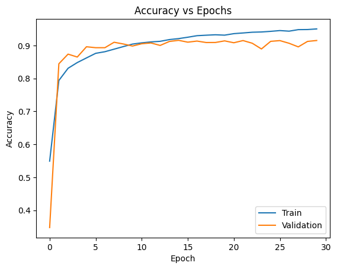

```python
# Fit training dataset to model
history_4 = cnn_model_2.fit(x_train_cnn_normalized, y_train_cnn_encoded, validation_split=0.2, batch_size = 128, epochs=30, verbose=1)

# Obtain training and validation accuracies from history_4
plt.plot(history_4.history['accuracy'])
plt.plot(history_4.history['val_accuracy'])
plt.title('Accuracy vs Epochs')
plt.ylabel('Accuracy')
plt.xlabel('Epoch')
plt.legend(['Train', 'Validation'], loc='lower right')
plt.show()
```

**Observations:*__***

- This CNN model has fewer trainable parameters and is more complex than the previous CNN model.
- The validation loss initially decreased and then fluctuated between slight increases and decreases.
- The training loss decreased with each epoch.
- The overall loss for training and validation was the lowest with this model -- ending at 0.1468 for training and 0.4434 for validation.
- The accuracy of the train rose to just over 95%, and the validation accuracy 91%.
- This model used 164,362 training parameters.

## **Predictions on the test data**

- Make predictions on the test set using the second model.
- Print the obtained results using the classification report and the confusion matrix.
- Final observations on the obtained results.

### **Make predictions on the test data using the second model.**

```python
# Make predictions on the test set
y_pred_cnn_test = cnn_model_2.predict(x_test_cnn_normalized)
y_pred_cnn_test = [np.argmax(i) for i in y_pred_cnn_test]
```

**Note:** Earlier, we noticed that each entry of the target variable is a one-hot encoded vector, but to print the classification report and confusion matrix, we must convert each entry of y_test to a single label.

```
(18000,)
              precision    recall  f1-score   support

           0       0.90      0.95      0.93      1814
           1       0.89      0.93      0.91      1828
           2       0.94      0.90      0.92      1803
           3       0.90      0.89      0.89      1719
           4       0.94      0.92      0.93      1812
           5       0.90      0.92      0.91      1768
           6       0.92      0.88      0.90      1832
           7       0.92      0.94      0.93      1808
           8       0.93      0.88      0.90      1812
           9       0.90      0.92      0.91      1804

    accuracy                           0.91     18000
   macro avg       0.91      0.91      0.91     18000
weighted avg       0.91      0.91      0.91     18000
```

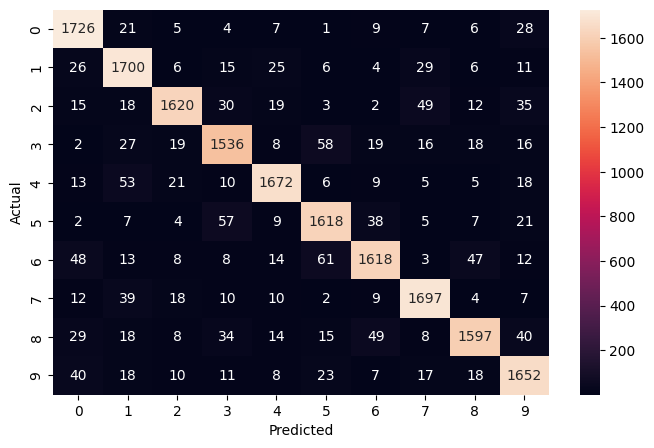

```python
# Convert y_test to a single label
y_test_cnn_single_label = np.argmax(y_test_cnn_encoded, axis=1)

# Print y_test_single_label
print(y_test_cnn_single_label.shape)

# Print classification report
print(classification_report(y_test_cnn_single_label, y_pred_cnn_test))

# Set up confusion matrix
cm_2 = confusion_matrix(y_test_cnn, y_pred_cnn_test)
plt.figure(figsize = (8,5))
sns.heatmap(cm_2, annot = True, fmt= '.0f')
plt.ylabel('Actual')
plt.xlabel('Predicted')

# Show matrix
plt.show()
```

### **Write your final observations on the performance of the model on the test data.**

**Final Observations:**_****

- With the latest CNN model, the accuracy for the test was 91%.
- The most accurately predicted classification was 0 with 1726 accurate instances.
- The most inaccurate predictions was:
  - Prediction of 5 when it was actually 6 in 61 instances.
- When considering all four models, this model had the highest accuracy and overall lowest loss values. Thus, cnn_model_2 is recommended.